# Wrangling: Routinely Randomize Potential Sources of Measurement Reactivity to Estimate and Adjust for Biases in Subjective Reports

Here, we wrangle the data into shape. We mainly work with the raw long-form data (`s3_daily_id`), which has one row per person, diary day, and item. We merge in some information from the wide-form diary data (one row per person and diary day) that has been cleaned as part of another study to get information on reasons for excluding data points and some other metadata.

## 0.1 Load R packages

```r
options(stringsAsFactors = FALSE)
#' show two significant digits tops
options(digits = 2)
#' tend not to show scientific notation, because we're just psychologists
options(scipen = 7)
#' make output a bit wider
options(width = 110)
#' set a seed to make analyses depending on random number generation reproducible
set.seed(1710) # if you use your significant other's birthday make sure you stay together for the sake of reproducibility


#' ## Load packages
#' generate the site
library(rmarkdown)
#' set options for chunks
library(knitr)
#' my formr utility package to generate e.g. the bibliography
library(formr)
#' pretty-printed output
library(pander)
#' tidyverse date times
library(lubridate)
#' tidyverse strings
library(stringr)
#' extractor functions for models
library(broom)
#' grammar of graphics plots
library(ggplot2)
#' svg graphs
# library(svglite);
library(feather)
library(ggthemes)
library(codebook)
library(kableExtra)
library(Cairo)
library(paletteer)
library(broom.mixed)
#' tidyverse: has a lot of naming conflicts, so always load last
library(tidyverse)
opts_chunk$set(warning = F, message = F, error = TRUE,
               fig.width = 15, fig.height = 8, dev = "CairoPNG")

#' tidylog explains what is happening in our pipes
library(tidylog)
options(width = 4000)
```

## 0.2 Load pre-cleaned wide diary data

We exclude days outside the participation period (first 70 days after starting), which means excluding a small percentage of cases who went over this period because of programming errors etc.

```r
load("../routine_and_sex/cleaned_selected.rdata")
diary = diary %>%
  filter(!is.na(session), !is.na(created_date)) %>%
  group_by(session) %>%
  mutate(days_done = max(days_done, na.rm = T),
         finished_first_page = if_else(!is.na(illness_pain), day_number, NA_real_),
         didntmissfirstweek = all(0:6 %in% finished_first_page, na.rm = TRUE),
         first_day = if_else(day_number == 0, 1, 0)) %>%
  ungroup() %>%
  filter(day_number >= 0, day_number < 70) %>%
  mutate(session = as.factor(stringr::str_sub(session, 1, 7)))
```

## 0.3 Load item metadata

To determine the conditions under which attempts were shown and to translate labels.

```r
questions <- rio::import("s3_daily_revised.xlsx")
questions <- questions %>%
  filter(!is.na(label_en), label_en != "") %>%
  mutate_if(is.character, ~ if_na(., "")) %>%
  select(type:label_en, showif)
```

Exclude some days (most exclusion criteria are menstrual cycle specific and irrelevant here).

```r
diary <- diary %>% filter(! reasons_for_exclusion %contains% "didnt_do_diary,",
                                ! reasons_for_exclusion %contains% "dishonest_answer,")
```

## 0.4 Load and process long-form diary data

```r
# s3_daily_id = jsonlite::fromJSON("../routine_and_sex/data/s3_daily_itemdisplay.json")
# rio::export(s3_daily_id, "../routine_and_sex/data/s3_daily_itemdisplay.feather")
s3_daily_id <- rio::import("../routine_and_sex/data/s3_daily_itemdisplay.feather")

#  s3_daily_id  %>%
#    distinct(session) %>%
#   filter(is.na(session) | session %contains% "XXX")
#

# set proper types
s3_daily_id = s3_daily_id  %>%
  filter(!is.na(session), !session %contains% "XXX") %>%
  mutate(
    created = as.POSIXct(created),
    answered_relative = as.numeric(answered_relative),
    shown_relative = as.numeric(shown_relative),
    display_order = as.numeric(display_order),
    hidden = as.numeric(hidden),
    unit_session_id = as.numeric(unit_session_id),
    saved = as.POSIXct(saved),
    answered = as.POSIXct(answered),
    shown = as.POSIXct(shown),
    time_to_response_server = answered - shown,
    time_to_response = answered_relative - shown_relative,
    session = as.factor(stringr::str_sub(session, 1, 7)),
    hidden = if_else(!is.na(answer), 0,
                          if_else(hidden == 0, 0,
                          1, 1))
  )
```

Compute dates for each diary day

```r
s3_daily_id = s3_daily_id  %>%
  group_by(session) %>% # group by woman
    mutate( # turn item showtimes into dates
      created_date = as.Date(created - hours(10)),
      first_created_date = min(created_date, na.rm = TRUE)) %>% # day of starting the diary
  group_by(session, unit_session_id) %>% # group by diary entry
    mutate(
      refer_time_period = answer[item_name == "refer_time_period"][1], # what time period was this entry referring to
      created_date = min(created_date, na.rm = TRUE)) %>%  # date of this entry
  ungroup()
```

```r
non_unique_dates <- s3_daily_id %>%
  group_by(session, created_date) %>%
  filter(n_distinct(unit_session_id) > 1)
# for 23 days there is some minor duplication
nrow(non_unique_dates %>% group_by(session, created_date) %>% summarise(n()))
```

```
## [1] 23
```

```r
# non_unique_dates %>% group_by(session, unit_session_id, created_date) %>% mutate(answered = sum(!is.na(answer))) %>%  filter(item_name == "illness_pain") %>% select(session, unit_session_id, created_date, answer, answered, day_number, created) %>% View

# some diagnostic checking
# only_in_diary <- setdiff(diary %>% filter(!is.na(created_diary)) %>% select(session, created_date), s3_daily_id %>% select(session, created_date))
# # only_in_diary %>% select(session) %>% slice(1) %>% left_join(diary)%>% select(session, day_number,created_date, created_diary, ended_diary) %>% arrange(session, day_number) %>% distinct() %>% View("diary")
# # only_in_diary %>% select(session) %>% slice(1) %>% left_join(s3_daily_id) %>% select(session, day_number, unit_session_id, created_date) %>% arrange(session, day_number) %>% distinct() %>% View("id")
# #
# # only_in_diary %>% select(session) %>% slice(8) %>% left_join(s3_daily_id) %>% select(session, day_number, unit_session_id, created_date) %>% arrange(session, day_number) %>% distinct() %>%
# #   full_join(only_in_diary %>% select(session) %>% slice(8) %>% left_join(diary)%>% select(session, day_number,created_date, created_diary, ended_diary) %>% arrange(session, day_number) %>% distinct() ,by=c("session","created_date")) %>% View
#
# only_in_id <- setdiff(s3_daily_id %>% select(session, created_date), diary %>% filter(!is.na(created_diary)) %>% select(session, created_date))
#
#
# # only_in_id %>% slice(1) %>% left_join(s3_daily_id) %>% select(session, day_number, unit_session_id, created_date) %>% arrange(session, day_number) %>% distinct()  %>% mutate(id_only = 1) %>%
# #   full_join(only_in_id %>% select(session) %>% slice(1) %>% left_join(diary) %>% select(session, day_number,created_date, created_diary, ended_diary) %>% arrange(session, day_number) %>% distinct() ,by=c("session","created_date"), suffix = c("_id", "_diary")) %>% View
# #
# # only_in_id %>% select(session) %>% slice(1) %>% left_join(diary)%>% select(session, day_number,created_date, created_diary, ended_diary) %>% arrange(session, day_number) %>% distinct() %>% View("diary")
# # only_in_id %>% select(session) %>% slice(1) %>% left_join(s3_daily_id) %>% select(session, day_number, unit_session_id, created_date) %>% arrange(session, day_number) %>% distinct() %>% View("id")
#
# in_both <- intersect(s3_daily_id %>% select(session, created_date), diary %>% filter(!is.na(created_diary)) %>% select(session, created_date))
#
# cbind(id_only = nrow(only_in_id), diary_only = nrow(only_in_diary),both= nrow(in_both))


## throw out non-unique dates
s3_daily_id <- s3_daily_id %>%
  group_by(session, created_date) %>%
  filter(n_distinct(unit_session_id) == 1)


## merge with diary, throw out dishonest reporting, days outside range etc.
s3_daily_id = s3_daily_id  %>%
  inner_join(diary %>% select(session, created_date, day_number, ended_diary, weekday, weekend), by = c("session", "created_date")) %>%
  group_by(session) %>%
    mutate(didntmissfirstweek = all(0:6 %in% day_number)) %>%   # did they do they whole first week
  ungroup()
```

Compute randomised variables.

```r
## compute relevant variables
s3_daily_id = s3_daily_id  %>%
  group_by(session, item_name) %>%
    mutate(
      first_day_of_item = min(c(Inf, day_number[!is.na(answer)])), # compute first day item was answered
      first_day_of_item = if_else(is.finite(first_day_of_item),    # treat problems
                                       first_day_of_item,
                                       NA_real_),
      first_day_of_item_factor = if_else(first_day_of_item > 6, "7+", as.character(first_day_of_item)), #categorise
      first_day_of_item_shown = first_day_of_item == day_number) %>% # dummy for the day the item was first shown
 ungroup() %>%
 mutate(first_day_of_item_factor = factor(first_day_of_item_factor))

crosstabs(~ (!is.na(displaycount) & displaycount>0) + hidden + is.na(answer), data = s3_daily_id)
```

```
## , , is.na(answer) = FALSE
##
##                                        hidden
## !is.na(displaycount) & displaycount > 0       0       1
##                                   FALSE       0       0
##                                   TRUE  4011516       0
##
## , , is.na(answer) = TRUE
##
##                                        hidden
## !is.na(displaycount) & displaycount > 0       0       1
##                                   FALSE       0 3827283
##                                   TRUE    13640 1806231
```

```r
# s3_daily_id <- s3_daily_id %>%
#   left_join(
#     diary_items %>%
#       rename(item_name = name) %>%
#       select(item_name, label, showif, choices),
#     "item_name")
s3_daily_id <- s3_daily_id  %>% left_join(
  questions %>%
  select(item_name = name, label_english = label_en, item_type = type, showif)
)

s3_daily_id = s3_daily_id %>%
  group_by(session, item_name) %>%
  arrange(session, item_name, unit_session_id) %>%
  mutate(times_item_answered = cumsum(!is.na(answer))) %>%
  ungroup() %>%
  mutate(
    times_item_answered_factor = factor(if_else(times_item_answered > 6, "7+", as.character(times_item_answered))),
    day_number_factor = factor(if_else(day_number > 6, "7+", as.character(day_number))),
    refer_time_period = recode(factor(refer_time_period), "in den letzten 24 Stunden" = "last 24 hours", "seit meinem letzten Eintrag" = "last entry"),
    label = label_english
)
```

Focus on questions that were answered to make it easier to compute display order and last item.

```r
s3_daily_id_answered = s3_daily_id %>%
  filter(!is.na(answer)) %>%
  group_by(session, unit_session_id) %>%
  mutate(number_of_items_shown = n()) %>%
  arrange(session, unit_session_id, display_order) %>%
  group_by(session, unit_session_id) %>%
  mutate(
    last_answer = lag(answer),
    response_time_since_previous = answered_relative - lag(answered_relative),
    response_time_pl_sp = if_else(is.na(response_time_since_previous),
                                  if_else(
                                    answered_relative == min(answered_relative, na.rm = TRUE),
                                    answered_relative - shown_relative,
                                    NA_real_),
                                  response_time_since_previous)) %>%
  ungroup()
```

focus on rating items, subject of this investigation anyway, to compute item means and SDs

```r
s3_daily_id_answered <- s3_daily_id_answered %>%
  filter(item_type %starts_with% "rating") %>%
  mutate(answer = as.numeric(answer)) %>%
  group_by(label_english) %>%
  mutate(item_mean = mean(answer, na.rm = T),
         item_sd = sd(answer, na.rm = T)) %>%
  ungroup()
```

Count number of randomised items per day

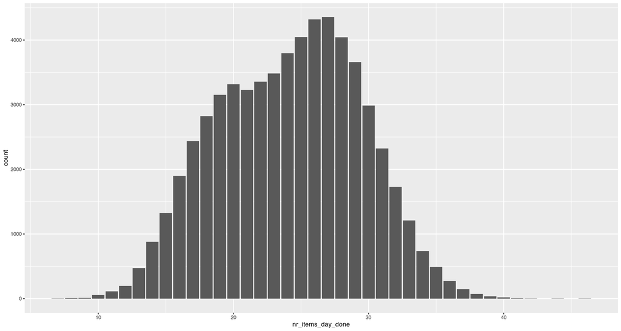

```r
s3_daily_nr_items <- s3_daily_id %>%
  drop_na(created) %>%
  group_by(session, unit_session_id, created_date) %>%
  summarise(nr_items_day = sum(hidden == 0 & showif %contains% "runif", na.rm = TRUE))

diary <- diary %>% ungroup()
diary <- s3_daily_nr_items %>%
  ungroup() %>%
  select(session) %>%
  distinct() %>%
  left_join(diary) %>%
  left_join(s3_daily_nr_items, by = c("session", "created_date"))


diary <- diary %>%
  mutate(skipped_day = if_else(is.na(ended_diary), 1, 0),
         did_not_finish_entry = if_else(is.na(ended_diary) | is.na(illness_pain), 1, 0),
         nr_items_day_done = if_else(did_not_finish_entry == 1, NA_integer_, nr_items_day)) %>%
  group_by(session) %>%
  arrange(created_date) %>%
  mutate(
    lag_nr_items_day = lag(nr_items_day_done),
    lag_finished_entry = lag(did_not_finish_entry)) %>%
  ungroup()

ggplot(diary, aes(nr_items_day_done)) +
  geom_bar()
```

```r
crosstabs(~ is.na(illness_pain) + did_not_finish_entry, diary)
```

```
##                    did_not_finish_entry
## is.na(illness_pain)     0     1
##               FALSE 60982   617
##               TRUE      0 15341
```

## 0.5 Sanity checks

```r
library(testthat)
expect_null(groups(diary))
expect_equal(diary %>% drop_na(session, day_number) %>%
               group_by(session, day_number) %>% filter(n() > 1) %>% nrow(), 0)
expect_equal(s3_daily_id_answered %>%
               group_by(session, day_number, item_name) %>% filter(n() > 1) %>% nrow(), 0)
```

## 0.6 Save data

Remove unused variables to reduce risk of re-identification

```r
s3_daily_id_answered <- s3_daily_id_answered %>%
  select(session, didntmissfirstweek, # person level
         unit_session_id, day_number, weekday, weekend, ended_diary, refer_time_period, day_number_factor,   # day level
         item_name, label, label_english, item_mean, item_sd, item_type,  # item level
         answer, display_order, hidden, # person x day x item response level
         first_day_of_item, first_day_of_item_factor, first_day_of_item_shown, showif,
         times_item_answered, times_item_answered_factor,
         number_of_items_shown, last_answer, response_time_since_previous) %>%
    filter(item_name %in% c("irritable", "self_esteem", "risk_taking", "good_mood", "loneliness", "stressed", "relationship_satisfaction",
                           "in_pair_desire_7", "in_pair_desire_8", "in_pair_desire_10", "in_pair_desire_11", "in_pair_desire_13", "in_pair_desire_14") |
         item_name %contains% "mate_retention" | item_name %starts_with% "time_")


key <- keyring::key_get_raw("encrypt_data_routinely_randomise")
class(key) <- c("aes", "raw")
library(cyphr)
key <- cyphr::key_openssl(key)
encrypt(saveRDS(s3_daily_id_answered, "s3_daily_id_answered.rds"), key)
encrypt(write.csv(s3_daily_id_answered, "s3_daily_id_answered.csv"), key)

stopifnot(!is.null(var_label(diary$relationship_status))) # keep labels

diary <- diary %>% select(session, didntmissfirstweek, hetero_relationship,
                          age, education_years, has_children, nr_children, relationship_status,
                          occupational_status,
                          day_number, did_not_finish_entry, skipped_day, lag_finished_entry,
                          nr_items_day_done, lag_nr_items_day)
encrypt(saveRDS(diary, "diary.rds"), key)
encrypt(write.csv(diary, "diary.csv"), key)
```

## 0.7 How key was set

```r
keyring::key_set("encrypt_data_routinely_randomise")
# entered key (precisely 16/24/32 characters long)
```